# Milestone_1_NLP_1

## Problem Statement:

Manual assignment of incidents is time consuming and requires human efforts. There may be mistakes due to human errors and resource consumption is carried out ineffectively because of the misaddressing. On the other hand, manual assignment increases the response and resolution times which result in user satisfaction deterioration / poor customer service.

In the support process, incoming incidents are analyzed and assessed by organization’s support teams to fulfill the request. In many organizations, better allocation and effective usage of the valuable support resources will directly result in substantial cost savings.

## Data Description:

- Short Description : This is the subject of the ticket.
- Description: This explains the ticket in detail.
- Caller: The person who has registered the ticket.
- Assignment Group : To which group does the ticket belong to. There are 74 unique group from 0-73. Most of them registered as grp_0.

```python
import numpy as np
import pandas as pd
import matplotlib.pyplot as plt
import seaborn as sns
import string
import os
from tensorflow.keras.utils import to_categorical
from sklearn.utils import class_weight
from tensorflow.keras.preprocessing.text import Tokenizer
from tensorflow.keras.preprocessing.sequence import pad_sequences
from tensorflow.keras.layers import Dense, Input, LSTM, Embedding, Dropout, Activation, Flatten, Bidirectional, GlobalMaxPool1D, BatchNormalization,SpatialDropout1D
from tensorflow.keras.models import Model, Sequential
from tensorflow.keras import initializers, regularizers, constraints, optimizers, layers
from tensorflow.keras.optimizers import Adam
from tensorflow.keras.callbacks import *
from tensorflow.keras import backend as K
from sklearn import model_selection
from sklearn.naive_bayes import GaussianNB
from sklearn.linear_model import LogisticRegression
from sklearn.neighbors import KNeighborsClassifier
from sklearn.tree import DecisionTreeClassifier
from sklearn import svm
from sklearn import tree
from sklearn.model_selection import train_test_split
from sklearn import preprocessing
from sklearn import metrics
from sklearn.feature_extraction.text import TfidfVectorizer
from scipy.stats import zscore
```

```python
import nltk
nltk.download('stopwords')
nltk.download('wordnet')
nltk.download('punkt')
nltk.download('averaged_perceptron_tagger')
from nltk.tokenize import RegexpTokenizer
from nltk.stem import WordNetLemmatizer,PorterStemmer
from nltk.corpus import stopwords
import re
import string
from sklearn.model_selection import train_test_split
from collections import OrderedDict

from wordcloud import WordCloud, STOPWORDS
```

```python
from google.colab import drive
drive.mount('/gdrive')
```

```
Mounted at /gdrive
```

```python
data = pd.read_excel('/content/drive/MyDrive/PGP_AIML_CapstoneProject/input_data (3).xlsx',index_col= None)
```

```python
data.shape
```

```
(8500, 4)
```

```python
data.head()
```

|  | Short description | Description | Caller | Assignment group |
| --- | --- | --- | --- | --- |
| 0 | login issue | -verified user details.(employee# & manager na... | spxjnwir pjlcoqds | GRP_0 |
| 1 | outlook | \r\n\r\nreceived from: hmjdrvpb.komuaywn@gmail... | hmjdrvpb komuaywn | GRP_0 |
| 2 | cant log in to vpn | \r\n\r\nreceived from: eylqgodm.ybqkwiam@gmail... | eylqgodm ybqkwiam | GRP_0 |
| 3 | unable to access hr_tool page | unable to access hr_tool page | xbkucsvz gcpydteq | GRP_0 |
| 4 | skype error | skype error | owlgqjme qhcozdfx | GRP_0 |

```python
data['Assignment group'].nunique()
```

```
74
```

Data Info:

- Data is highly imbalanced between Group-0 and rest of the Assignment Groups
- Short Description and Description columns will be making the Corpus of the Model
- Data seems to be a free text and does not have defined structure or format
- Similar text content in the incidents is assigned to multiple Assignment Groups in few cases
- One of the observations is that Large set of incidents are generated by same Caller
- The Callers are free to create incidents in any Language and hence we can find roughly 8 to 10% of incidents in languages other than English
- Large set of incidents are auto generated by the digital robot and do have same text content with Job Scheduler Id, Date, time stamp etc.

```python
data.info()
```

```
<class 'pandas.core.frame.DataFrame'>
RangeIndex: 8500 entries, 0 to 8499
Data columns (total 4 columns):
 #   Column             Non-Null Count  Dtype
---  ------             --------------  -----
 0   Short description  8492 non-null   object
 1   Description        8499 non-null   object
 2   Caller             8500 non-null   object
 3   Assignment group   8500 non-null   object
dtypes: object(4)
memory usage: 265.8+ KB
```

```python
data.isnull().sum()
```

```
Short description    8
Description          1
Caller               0
Assignment group     0
dtype: int64
```

```python
data.dropna(inplace=True)
```

```python
data.head()
```

|  | Short description | Description | Caller | Assignment group |
| --- | --- | --- | --- | --- |
| 0 | login issue | -verified user details.(employee# & manager na... | spxjnwir pjlcoqds | GRP_0 |
| 1 | outlook | \r\n\r\nreceived from: hmjdrvpb.komuaywn@gmail... | hmjdrvpb komuaywn | GRP_0 |
| 2 | cant log in to vpn | \r\n\r\nreceived from: eylqgodm.ybqkwiam@gmail... | eylqgodm ybqkwiam | GRP_0 |
| 3 | unable to access hr_tool page | unable to access hr_tool page | xbkucsvz gcpydteq | GRP_0 |
| 4 | skype error | skype error | owlgqjme qhcozdfx | GRP_0 |

```python
data.tail()
```

|  | Short description | Description | Caller | Assignment group |
| --- | --- | --- | --- | --- |
| 8495 | emails not coming in from zz mail | \r\n\r\nreceived from: avglmrts.vhqmtiua@gmail... | avglmrts vhqmtiua | GRP_29 |
| 8496 | telephony_software issue | telephony_software issue | rbozivdq gmlhrtvp | GRP_0 |
| 8497 | vip2: windows password reset for tifpdchb pedx... | vip2: windows password reset for tifpdchb pedx... | oybwdsgx oxyhwrfz | GRP_0 |
| 8498 | machine não está funcionando | i am unable to access the machine utilities to... | ufawcgob aowhxjky | GRP_62 |
| 8499 | an mehreren pc`s lassen sich verschiedene prgr... | an mehreren pc`s lassen sich verschiedene prgr... | kqvbrspl jyzoklfx | GRP_49 |

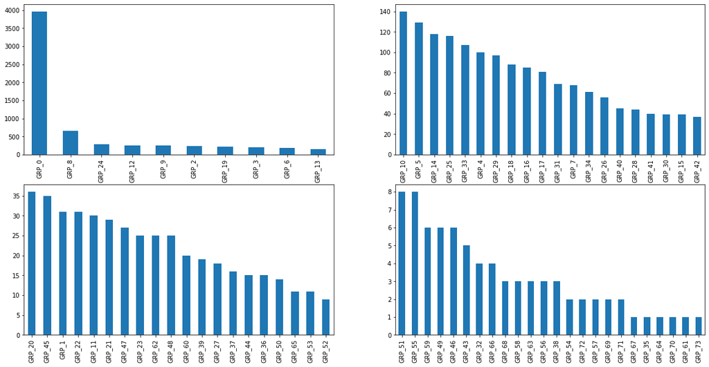

```python
fig,axs = plt.subplots(2,2, sharex=False, figsize=(20,10))

data['Assignment group'].value_counts()[0:10].plot(kind='bar',  ax=axs[0, 0])
data['Assignment group'].value_counts()[10:30].plot(kind='bar', ax=axs[0, 1])
data['Assignment group'].value_counts()[30:50].plot(kind='bar', ax=axs[1, 0])
data['Assignment group'].value_counts()[50:74].plot(kind='bar', ax=axs[1, 1])

plt.show()
```

## Summary of Data:

# Feature Engineering:

```python
from sklearn.utils import resample

major_data = data[data['Assignment group'].isin(data['Assignment group'].value_counts()[data['Assignment group'].value_counts() > 100].index)]
minor_data = data[data['Assignment group'].isin(data['Assignment group'].value_counts()[data['Assignment group'].value_counts() < 100].index)]

print(major_data.shape)

minor_data = resample(minor_data, replace=True, n_samples=len(major_data),random_state=438)

print(minor_data.shape)

upsampled_data = pd.concat([minor_data, major_data])
print(upsampled_data.shape)
```

```
(7022, 4)
(7022, 4)
(14044, 4)
```

```python
data = upsampled_data.copy()
```

```python
data.Description.fillna("Is", inplace=True)
data['Short description'].fillna("Is", inplace=True)
data = data.dropna(subset=["Assignment group"])
data = data.drop(['Caller'], 1)
```

```python
data.head()
```

|  | Short description | Description | Assignment group |
| --- | --- | --- | --- |
| 7835 | no connection to the production_order_interfac... | hello,\r\n\r\nwe have no connection to the pls... | GRP_45 |
| 5797 | problem with erp not updating orders after get... | problem with erp not updating orders after get... | GRP_18 |
| 952 | collaboration_platform system not working | the collaboration_platform system is not worki... | GRP_16 |
| 7422 | telephony_software_2016r2_installation - upgra... | \r\n\r\nreceived from: zjcsqtdn.jikyworg@gmail... | GRP_65 |
| 6198 | ng_azubi locked | ng_azubi locked | GRP_34 |

# EDA And Preprocessing:

- We will look into the wordcloud of the column description before and after preprocessing.
- Preprocessing is the way of cleaning data before we start modelling it.
- While preprocessing, we will normalize the data, remove punctuations, numbers, website address, words like "xyzgmailcom".

## Wordcloud before Data Preprocessing:

```
<wordcloud.wordcloud.WordCloud object at 0x7f1f73b810d0>
```

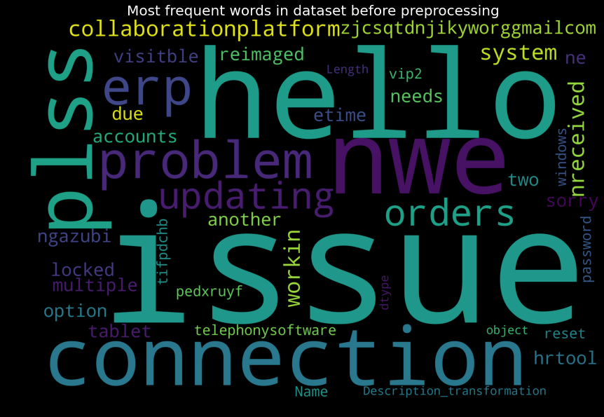

```python
wc = WordCloud(width = 3000,
    height = 2000,
    background_color = 'black',
    stopwords = STOPWORDS)

# generate word cloud for data before preprocessing
wc_word=wc.generate(str(data.Description))
print(wc_word)

# declare our figure
plt.figure(figsize=(20,10), facecolor='k')

# add title to the graph
plt.title("Most frequent words in dataset before preprocessing", fontsize=20,color='white')
plt.imshow(wc_word)
plt.show()
```

## Removing columns Caller and short description from the data.

```python
data.drop(['Short description'], axis=1, inplace=True)
```

```python
lemmatizer = WordNetLemmatizer()
stemmer = PorterStemmer()
```

```python
def preprocess(sentence):
    sentence=str(sentence)
    sentence = sentence.lower()
    sentence = sentence.replace('{html}',"")
    cleanr = re.compile('<.*?>')
    cleantext = re.sub(cleanr, '', sentence)
    rem_email = re.sub('\S+@+\S+[.com]','',cleantext)
    rem_special = re.sub(r'[_"\-;%()|~^+&=*%.,!?:#$@\[\]/]', ' ', rem_email)
    rem_url=re.sub(r'http\S+', '',rem_special)
    rem_num = re.sub('[0-9]+', '', rem_url)
    tokenizer = RegexpTokenizer(r'\w+')
    tokens = tokenizer.tokenize(rem_num)
    filtered_words = [w for w in tokens if len(w) > 2 if not w in stopwords.words('english')]
    # filtered_words = [w for w in tokens if not w in stopwords.words('english')]
    stem_words=[stemmer.stem(w) for w in filtered_words]
    lemma_words=[lemmatizer.lemmatize(w) for w in stem_words]
    return " ".join(filtered_words)
```

## Data Pre-processing:

```python
data['Description_transformation'] = data['Description_transformation'].apply(lambda x: preprocess(x))
```

```python
data.head()
```

|  | Description | Assignment group | Description_transformation |
| --- | --- | --- | --- |
| 7835 | hello,\r\n\r\nwe have no connection to the pls... | GRP_45 | hello connection plssealdfu server think serve... |
| 5797 | problem with erp not updating orders after get... | GRP_18 | problem erp updating orders getting picked war... |
| 952 | the collaboration_platform system is not worki... | GRP_16 | collaborationplatform system working multiple ... |
| 7422 | \r\n\r\nreceived from: zjcsqtdn.jikyworg@gmail... | GRP_65 | received zjcsqtdnjikyworggmailcom mit freundli... |
| 6198 | ng_azubi locked | GRP_34 | ngazubi locked |

```python
data['Description_transformation'] = data['Description_transformation'].apply(lambda x: re.sub(r'\w+[com]','',x))
```

```python
data.head()
```

|  | Description | Assignment group | Description_transformation |
| --- | --- | --- | --- |
| 7835 | hello,\r\n\r\nwe have no connection to the pls... | GRP_45 | n plssealdfu server think server cant print n... |
| 5797 | problem with erp not updating orders after get... | GRP_18 | erp updating orders getting ked l |
| 952 | the collaboration_platform system is not worki... | GRP_16 | rking multiple users rt getting r trying ope... |
| 7422 | \r\n\r\nreceived from: zjcsqtdn.jikyworg@gmail... | GRP_65 | eived mit hen grã¼ãÿen best |
| 6198 | ng_azubi locked | GRP_34 | ngazubi ked |

## Wordcloud After Data preprocessing:

```
<wordcloud.wordcloud.WordCloud object at 0x7f1f6de64490>
```

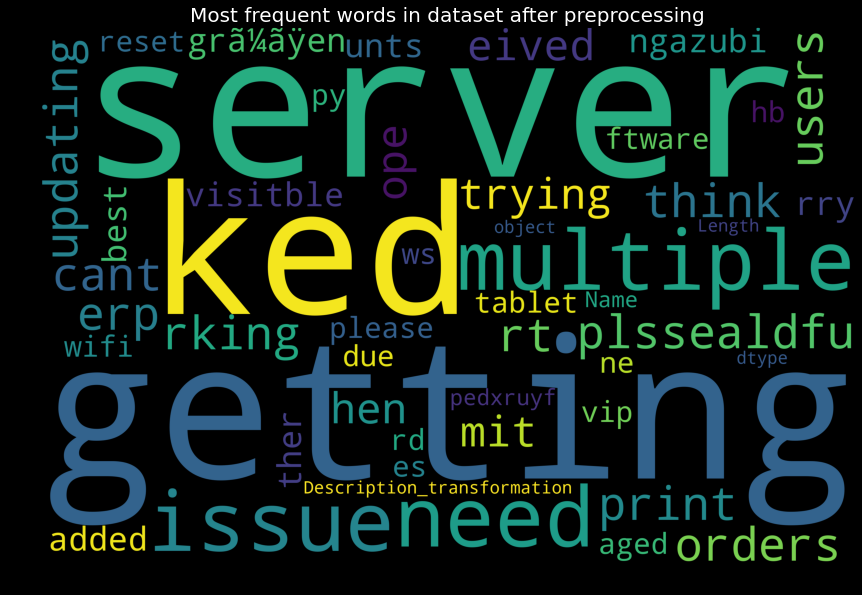

```python
wc = WordCloud(width = 3000,
    height = 2000,
    background_color = 'black',
    stopwords = STOPWORDS)

# generate word cloud for preprocessed data
wc_word=wc.generate(str(data.Description_transformation))
print(wc_word)

# declare our figure
plt.figure(figsize=(20,10), facecolor='k')

# add title to the graph
plt.title("Most frequent words in dataset after preprocessing", fontsize=20,color='white')
plt.imshow(wc_word)
plt.show()
```

## Model Building:

```python
from sklearn import preprocessing
label_encoder = preprocessing.LabelEncoder()

y = label_encoder.fit_transform(data['Assignment group'])
```

```python
X_train, X_test, y_train, y_test = train_test_split(data['Description_transformation'],data['Assignment group'] ,test_size=0.20, random_state=80)
```

```python
display(X_train.shape, X_test.shape, y_train.shape, y_test.shape)
```

```
(11235,)
```

```
(2809,)
```

```
(11235,)
```

```
(2809,)
```

```python
vectorizer = TfidfVectorizer()
vectorizer.fit(X_train)
X_train = vectorizer.transform(X_train)
X_test = vectorizer.transform(X_test)
X_train, X_test
```

```
(<11235x8578 sparse matrix of type '<class 'numpy.float64'>'
 	with 124348 stored elements in Compressed Sparse Row format>,
 <2809x8578 sparse matrix of type '<class 'numpy.float64'>'
 	with 28009 stored elements in Compressed Sparse Row format>)
```

## Logistic Regression:

- Logistic regression is usually among the first few topics which people pick while learning predictive modeling.
- Logistic regression is not a regression algorithm but a probabilistic classification model
- Multiclass classification with logistic regression can be done either through the one-vs-rest scheme in which for each class a binary classification problem of data belonging or not to that class is done, or changing the loss function to cross- entropy loss.
- Logistic Regressor uses Sigmoid function

```python
import warnings
warnings.filterwarnings('ignore')
```

```python
model = LogisticRegression()
model.fit(X_train, y_train)

%time

y_predict = model.predict(X_test)


count_misclassified = (y_test != y_predict).sum()
print('Misclassified samples: {}'.format(count_misclassified))
accuracy = metrics.accuracy_score(y_test, y_predict)
print('Accuracy: {:.2f}'.format(accuracy))


test_model_score = model.score(X_test, y_test)
train_model_score = model.score(X_train, y_train)

print("\nTest Accuracy ", test_model_score)
print("\nTrain Accuracy", train_model_score)
```

```
CPU times: user 7 µs, sys: 2 µs, total: 9 µs
Wall time: 9.3 µs
Misclassified samples: 871
Accuracy: 0.69

Test Accuracy  0.6899252402990388

Train Accuracy 0.757543391188251
```

## Naive Bayes:

- It is a classification technique based on Bayes’ Theorem with an assumption of independence among predictors.
- In simple terms, a Naive Bayes classifier assumes that the presence of a particular feature in a class is unrelated to the presence of any other feature.
- ! [Naive Bayes Formula](https://www.analyticsvidhya.com/wp-content/uploads/2015/09/Bayes_rule-300x172.png)

```python
from sklearn.naive_bayes import MultinomialNB
from sklearn.metrics import accuracy_score
model = MultinomialNB()
model.fit(X_train, y_train)

%time

y_predict = model.predict(X_test)
test_model_score = model.score(X_test, y_test)
train_model_score = model.score(X_train, y_train)

print("\nTest Accuracy ", test_model_score)
print("\nTrain Accuracy", train_model_score)
```

```
CPU times: user 3 µs, sys: 0 ns, total: 3 µs
Wall time: 7.39 µs

Test Accuracy  0.4058383766464934

Train Accuracy 0.4311526479750779
```

## K - Nearest Neighbour:

- The KNN algorithm assumes that similar things exist in close proximity. In other words, similar things are near to each other.
- The algorithm calculates the distance between two points to measure their similarity.
- There are other ways of calculating distance, and one way might be preferable depending on the problem we are solving. However, the straight-line distance (also called the Euclidean distance) is a popular and familiar choice.

```python
model = KNeighborsClassifier(n_neighbors=3 , weights = 'distance' )
model.fit(X_train, y_train)

%time

y_predict = model.predict(X_test)
test_model_score = model.score(X_test, y_test)
train_model_score = model.score(X_train, y_train)

print("\nTest Accuracy ", test_model_score)
print("\nTrain Accuracy", train_model_score)
```

```
CPU times: user 2 µs, sys: 1e+03 ns, total: 3 µs
Wall time: 8.11 µs

Test Accuracy  0.7080811676753292

Train Accuracy 0.9465954606141522
```

## SVM:

- Support vector machines (SVMs) are a set of supervised learning methods used for classification, regression and outliers detection.
- Effective in high dimensional spaces.
- Still effective in cases where number of dimensions is greater than the number of samples.

```python
model = svm.SVC(gamma=0.025, C=3)
model.fit(X_train, y_train)

%time

y_predict = model.predict(X_test)
test_model_score = model.score(X_test, y_test)
train_model_score = model.score(X_train, y_train)

print("\nTest Accuracy ", test_model_score)
print("\nTrain Accuracy", train_model_score)
```

```
CPU times: user 3 µs, sys: 1e+03 ns, total: 4 µs
Wall time: 17.2 µs

Test Accuracy  0.43823424706301173

Train Accuracy 0.47903871829105477
```

## Decision Tree:

- Decision tree classifier is a systematic approach for multiclass classification.
- It poses a set of questions to the dataset (related to its attributes/features).
- The decision tree classification algorithm can be visualized on a binary tree.

```python
model = DecisionTreeClassifier(criterion = 'gini', random_state=1)
model.fit(X_train, y_train)

%time

y_predict = model.predict(X_test)
test_model_score = model.score(X_test, y_test)
train_model_score = model.score(X_train, y_train)
print("\nTest Accuracy ", test_model_score)
print("\nTrain Accuracy", train_model_score)
```

```
CPU times: user 3 µs, sys: 0 ns, total: 3 µs
Wall time: 8.58 µs

Test Accuracy  0.782128871484514

Train Accuracy 0.9481085892300846
```

```python
from sklearn import tree
text_representation = tree.export_text(model)
print(text_representation)
```

[output not shown]

[output cut: 228 more lines]

[output not shown]

## Recurrent Neural Network:

- A recurrent neural network (RNN) is a class of artificial neural networks where connections between nodes form a directed graph along a temporal sequence.
- This allows it to exhibit temporal dynamic behavior. Derived from feedforward neural networks, RNNs can use their internal state (memory) to process variable length sequences of inputs.

```python
max_features = 10000
maxlen = 150
embedding_size = 200

X_train, X_test, y_train, y_test = train_test_split(data['Description_transformation'], y, test_size=0.20, random_state=42)

num_words=max_features
tokenizer = Tokenizer(num_words=10000)
tokenizer.fit_on_texts(X_train)

X_train = tokenizer.texts_to_sequences(X_train)
X_test = tokenizer.texts_to_sequences(X_test)

vocab_size = len(tokenizer.word_index) + 1

MAX_SEQUENCE_LENGTH = maxlen

X_train = pad_sequences(X_train, padding='pre', maxlen=MAX_SEQUENCE_LENGTH)
X_test = pad_sequences(X_test, padding='pre', maxlen=MAX_SEQUENCE_LENGTH)
```

```python
y_train = to_categorical(y_train)
y_test = to_categorical(y_test)
```

```python
display(tokenizer.word_counts, tokenizer.document_count, tokenizer.word_index, tokenizer.word_docs)
```

[output not shown]

[output cut: 946 more lines]

[output not shown]

```
11235
```

[output not shown]

[output cut: 946 more lines]

[output not shown]

[output not shown]

[output cut: 947 more lines]

[output not shown]

```python
inputs = Input(shape=(MAX_SEQUENCE_LENGTH, ))
embedding_layer = Embedding(vocab_size,
                            embedding_size,
                            input_length=MAX_SEQUENCE_LENGTH)(inputs)
print(embedding_layer)
# y = SpatialDropout1D(0.2)(embedding_layer)
# print(y)
x = Bidirectional(LSTM(128, dropout=0.2, recurrent_dropout=0.2, return_sequences=True))(embedding_layer)
print(x)
x = Bidirectional(LSTM(128))(x)
print(x)
x = Dense(100, activation='relu')(x)
x = BatchNormalization()(x)
x = Dropout(0.2)(x)
x = Dense(64, activation='relu')(x)

predictions = Dense(73, activation='softmax')(x)
model = Model(inputs=[inputs], outputs=predictions)

model.compile(optimizer='adam',
              loss='categorical_crossentropy',
              metrics=['acc'])

print(model.summary())
```

```
KerasTensor(type_spec=TensorSpec(shape=(None, 150, 200), dtype=tf.float32, name=None), name='embedding_3/embedding_lookup/Identity_1:0', description="created by layer 'embedding_3'")
KerasTensor(type_spec=TensorSpec(shape=(None, 150, 256), dtype=tf.float32, name=None), name='bidirectional_6/concat:0', description="created by layer 'bidirectional_6'")
KerasTensor(type_spec=TensorSpec(shape=(None, 256), dtype=tf.float32, name=None), name='bidirectional_7/concat:0', description="created by layer 'bidirectional_7'")
Model: "model_2"
_________________________________________________________________
Layer (type)                 Output Shape              Param #
=================================================================
input_4 (InputLayer)         [(None, 150)]             0
_________________________________________________________________
embedding_3 (Embedding)      (None, 150, 200)          1695800
_________________________________________________________________
bidirectional_6 (Bidirection (None, 150, 256)          336896
_________________________________________________________________
bidirectional_7 (Bidirection (None, 256)               394240
_________________________________________________________________
dense_8 (Dense)              (None, 100)               25700
_________________________________________________________________
batch_normalization_3 (Batch (None, 100)               400
_________________________________________________________________
dropout_3 (Dropout)          (None, 100)               0
_________________________________________________________________
dense_9 (Dense)              (None, 64)                6464
_________________________________________________________________
dense_10 (Dense)             (None, 73)                4745
=================================================================
Total params: 2,464,245
Trainable params: 2,464,045
Non-trainable params: 200
_________________________________________________________________
None
```

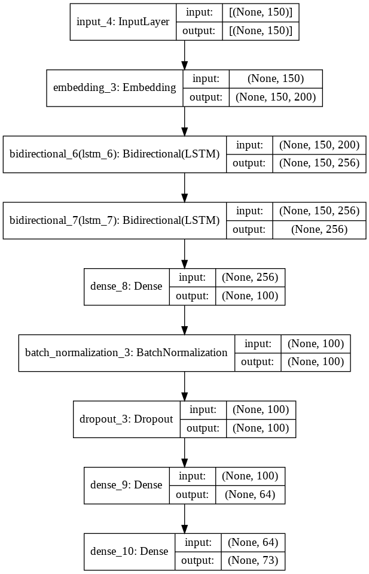

```python
from tensorflow.keras.utils import  plot_model
plot_model(model, to_file='model_lstm.png', show_shapes=True, show_layer_names=True)
```

```python
batch_size = 200
epochs = 15

# Fit the model
history = model.fit(X_train, y_train, batch_size, epochs, verbose=1, validation_data=(X_test, y_test))
```

[output not shown]

```python
%time

score,acc = model.evaluate(X_test, y_test, verbose=1)
print("Score: %.2f" % (score))
print("Accuracy: %.2f%%" % (acc*100))
```

```
CPU times: user 16 µs, sys: 3 µs, total: 19 µs
Wall time: 91.1 µs
Score: 1.17
Accuracy: 78.53%
```

## Summary of all the models:

```python
model_results = pd.DataFrame([('Logistic Regression Classifier', 75.75, 68.9),
                  ('Naive Bayes',43.11, 40.58),
                  ('K Nearest Neighour', 94.65, 70.80),
                  ('Support Vector Machine', 47.9, 43.82),
                  ('Decision Trees Classifier', 94.81, 78.21),
                  ('LSTM', 93.15, 78.53)],
                  columns=('Model Name', 'Train Accuracy','Test Accuracy'))

model_results
```

|  | Model Name | Train Accuracy | Test Accuracy |
| --- | --- | --- | --- |
| 0 | Logistic Regression Classifier | 75.75 | 68.90 |
| 1 | Naive Bayes | 43.11 | 40.58 |
| 2 | K Nearest Neighour | 94.65 | 70.80 |
| 3 | Support Vector Machine | 47.90 | 43.82 |
| 4 | Decision Trees Classifier | 94.81 | 78.21 |
| 5 | LSTM | 93.15 | 78.53 |

## How to improve your model performance?

- Translate German words to english.
- Minimizes the Human errors in identifies the appropriate groups
- Use Transfer Learning to make predictions more accurate.